# Probability and Statistics

The Basics of Probability

# Introduction

We said that **probability goes from models → data**.

What does this mean?

## What is a model?

- A **model** is a *mathematical description* of uncertain events
- Example:
  - A six-sided die → 6 possible outcomes {1,2,3,4,5,6}
  - With each outcome equally likely

## What do we do with the model?

Given the model, we can compute probabilities of events:

- $P(\text{roll a 6}) = \frac{1}{6}$
- $P(\text{roll a number} > 4) = \frac{2}{6} = \frac{1}{3}$ (favorable: $\{5,6\}$)
- $P(\text{roll an even number}) = \frac{3}{6} = \frac{1}{2}$ (favorable: $\{2,4,6\}$)

## Not what we’re doing

- We are **not** trying to *guess* the model
- We will do that in the **statistics** part of the course

Probability: assume a model → compute probabilities  
Statistics: use data → infer the model

## Where we go from here

- Models can get much more complicated:
  - multiple events, dependence, randomness in time, …
- Before that, we need some **terminology** and **vocabulary** to describe them.

# Random Variables

## What is a random variable?

Let’s say that I roll a dice, and I get a 4.

Is **4** a random variable?

4 is just a number, the outcome of the dice is a random variable, **before being observed**

## Let’s consider a few more examples:

Which of these would you say is a random variable?

- I roll a die **right now**
- I rolled a die **this morning**, but haven’t told you the result
- I **think of a number** in my head
- The **number of letters in my name**
- The number of cats I own

## Randomness Depends on Knowledge

Whether something is random depends on **your knowledge** of it.

If you don’t know the result of the die roll, or the number I thought of, you may model it as a random variable.

Randomness is a **modeling choice**, not a property of the world.

## A Practical Definition

A **random variable** is anything that we choose to model as random in order to make better decisions.

If modeling it as a random variable is useful, then it **is** a random variable, for you.

Examples:

- The weather tomorrow
- The arrival time of a bus

## A Formal Definition

An **Experiment** is a preocedure that

- is carried out under controlled conditions
- executed to discover an unknown result

An Experiment is a **Random Experiment** if it can result in different outcomes when performed in the same manner every time.

A random variable is the **outcome of a random experiment**.

# More Definitions

## Sample Spaces

The set of all possible outcomes of a random experiment is called the sample space, $S$.

- $S$ is **discrete** if it consists of a finite or countable infinite set of outcomes.
- $S$ is **continuous** if it contains an interval (either finite or infinite) of real numbers.

## Examples of Sample Spaces

**1. Rolling a Die**

- $S = \{1,2,3,4,5,6\}$
- Discrete, finite

**2. Tossing Two Coins**

- $S = \{(H,H), (H,T), (T,H), (T,T)\}$
- Discrete, finite

**3. Waiting Time for a Bus**

- $S = [0,\infty)$
- Continuous (any nonnegative real number)

## Example: Camera Flash

Get a random camera from a shop, and measure the cycle time of its flash  
(the time taken to ready the camera for another flash).

In general, the cycle time is a positive number, so it’s sample space would be.
$$S = \mathbb{R}^+ = \{x \mid x > 0\} \quad \text{(continuous)}$$

Suppose it is known that all recycle times are between 1.5 and 5 seconds.

$$S = \{x \mid 1.5 < x < 5\} \quad \text{(continuous)}$$

Suppose now that for a specific brand, there are only three possible values of cycle time.
$$S = \{\text{low}, \text{medium}, \text{high}\} \quad \text{(discrete)}$$

## Example: Camera Flash - cont.

A question about a random variable is itself a random variable.

Does the camera have a minimum cycle time that is longer than 2 seconds?

$$S = \{\text{yes}, \text{no}\} \quad \text{(discrete)}$$

## Events

An **event** is a subset of the sample space of an experiment.

Examples:

- Rolling an even number: $\{2, 4, 6\}$
- Two coins landing on the same side: $\{(H, H), (T, T)\}$
- A recycle time of at least 2 seconds: $\{x \in S | \ x \geq 2\}$

## Events, more formally

An **event** is any subset of the sample space $S$.

This includes:

- The entire sample space $S$
- The empty set $\varnothing$
- Any single outcome $\{x\}$
- Any union or intersection of outcomes

## The empty

- The **empty set** $\varnothing$ = the event with no outcomes

I roll a dice, and **no number is rolled**.

It’s impossible by definition.

## Elementary Events

- Each **single outcome** $\{x\}$ is called an **elementary event**
- Example:
  - $\{3\}$ when rolling a die
  - $\{H\}$ when tossing a coin

All other events are **unions** of elementary events:
$$A = \{2,4,6\} = \{2\} \cup \{4\} \cup \{6\}$$

## The Probability of an Event

The **probability** of an event is a number between 0 and 1 that quantifies how likely the event is to occur.

$$P(E) \in [0, 1], \quad \text{where } E \subseteq S$$

- $P(E) = 0$ ➜ impossible event
- $P(E) = 0.5$ ➜ event that occurs half of the times
- $P(E) = 1$ ➜ certain event

## Non-Uniform Probabilities

So far, we have always talked about cases where the outcomes were **equally likely**.

When toss a coin, all outcomes are equally likely.

This is not always the case.

## Example: COVID-19 Testing

- A person can be:
  - **Healthy (H)**
  - **Infected (I)**

But the two options are **not equally likely**, most people are healty.

# The Axioms of Probability

In mathematics, an **axiom** is a property we **assume to be true**, and use as the foundation for building the theory.

## Axioms of Probability

Probabilities must satisfy certain characteristics, these are called **Axioms of Probability**.

<br>

Let $S$ be the sample space and $E, F$ be events.

1. **Non-negativity**:
   $$P(E) \geq 0$$
2. **Normalization**:
   $$P(S) = 1$$
3. **Additivity** (for disjoint events):
   $$E \cap F = \emptyset, \quad \Rightarrow \quad P(E \cup F) = P(E) + P(F)$$

## Interpreting the Axioms

1. **Non-negativity**

A probability can **never be negative**  
A negative probability has no meaning, $P=0$ already means that an event is impossible

2. **Normalization**

The **entire sample space** has probability $1$  
Something in $S$ **must** happen: Rolling a die → one of $\{1,2,3,4,5,6\}$ will occur

3. **Additivity (disjoint events)**

If two events **cannot happen together**, their probabilities **add**

## Multiple Random Experiments

A **random experiment** produces an outcome from a sample space $S$.

Sometimes we perform **more than one experiment**:  
- Toss two coins  
- Roll two dice  
- Pick two cards from a deck

We can model **all experiments together** as **one random variable**  
with a sample space that contains all possible combined outcomes.

## Combining Probability Spaces

For multiple experiments, the **sample space** is the  
**Cartesian product** of the individual spaces:

$$S = S_1 \times S_2 = \{(x,y) \mid x \in S_1, y \in S_2\}$$

## Discrete Variables

If each experiment has a **finite number of outcomes**:

$$|S| = |S_1| \times |S_2|$$

Example:  
- Two dice → $6 \times 6 = 36$ outcomes  
- Two coins → $2 \times 2 = 4$ outcomes

## Example: Coin Tosses

Let $S_{\text{coin}} = \{ \text{H}, \text{T} \}$.

The combined sample space is the Cartesian product:  
$S = S_{\text{coin}} \times S_{\text{coin}}$.

| **Coin 1** | **Coin 2** | **Outcome** |
| --- | --- | --- |
| H | H | (H, H) |
| H | T | (H, T) |
| T | H | (T, H) |
| T | T | (T, T) |

$|S| = 4$

## Example: Message Delays

Messages are classified as on-time or late within the time specified by the system design. Use a tree diagram to represent the sample space of possible outcomes.

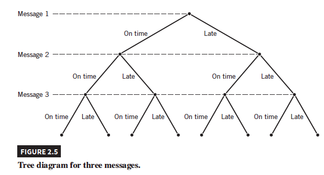

## Continuous Variables

When outcomes are **continuous**, combining experiments adds **dimensions** to the space.

## Example: Bus waiting times

Let:

- $X$ = delay for the **morning** bus
- $Y$ = delay for the **evening** bus

Each takes values in the interval $[0, M]$, so the sample spaces are:
$$S_X = [0, M], \quad S_Y = [0, M]$$

The **joint sample space** is the Cartesian product:

$$S = S_X \times S_Y = \{(x,y) : 0 \le x \le M,\, 0 \le y \le M\}$$

This is a **square** in the plane.

# Manipulating Events

## Set Operations on Events

Since events are sets of outcomes, we can perform **set operations** on them:

| **Operation** | **Symbol** | **Meaning** | **Interpretation** |
| --- | --- | --- | --- |
| Union | $A \cup B$ | $A$ **or** $B$ | At least one occurs |
| Intersection | $A \cap B$ | $A$ **and** $B$ | Both occur |
| Complement | $A^c$ or $A'$ | **Not** $A$ | A does not occur |

## Venn Diagrams

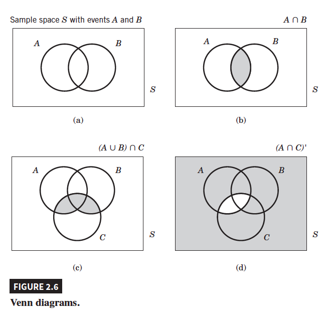

## Some Useful Intuitions

- The **union** of two events is always at least as likely as their intersection:
  $$P(A \cup B) \geq P(A \cap B)$$
- Specifically:
  $$P(A \cup B) = P(A) + P(B) - P(A \cap B)$$
- An **event and its complement** have total probability 1:
  $$P(A) + P(A^c) = 1$$
- If one event is a **subset** of another, its probability is less than or equal:
  $$A \subseteq B \Rightarrow P(A) \leq P(B)$$

## Example: roll of a die

Let the sample space be $S = \{1, 2, 3, 4, 5, 6\}$, representing a fair die roll.

$A = \{\text{even numbers}\} = \{2, 4, 6\}$

$B = \{\text{divisible by 3}\} = \{3, 6\}$

Then:

1. What is $A \cap B$?
2. What is $A \cup B$?
3. What is $A^c$?
4. What is $P(A)$?
5. What is $P(A \cup B)$?
6. What is $P(A \cap B)$?

# Laws for combining probabilities

## Independence of Events

Two events $A$ and $B$ are **independent** if knowing that $A$ happened does **not** change the probability of $B$.

For independent events it holds:

$$P(A \cap B) = P(A) \cdot P(B)$$

For three events $A,B,C$, **mutual independence** means:

$$P(A \cap B \cap C) = P(A)\,P(B)\,P(C)$$

And so on.

## Example: Tossing Two Coins

We toss two fair coins:

- $A$ = first coin is heads
- $B$ = second coin is heads

Both coins are **independent**, so
$$P(A \cap B) = P(A)\,P(B) = 0.5 \times 0.5 = 0.25$$

This gives us the probability of the **intersection**.

## What About the Union?

We want $P(A \cup B)$ = probability that **at least one coin** is heads.

We had a formula for
$$P(A \cup B) = P(A) + P(B) - P(A \cap B)$$

Is there an alternative way?

## Using Complements

We can use the **De Morgan’s Laws** for the complement:

$$(A \cup B)^c = A^c \cap B^c$$

If neither $A$ nor $B$ happens, then $A \cup B$ does **not** happen.

## The enemy of my enemy…

Double negations cancel each other out.

$$((A \cup B)^c)^c = (A^c \cap B^c)^c$$

Therefore:

$$A \cup B = (A^c \cap B^c)^c$$

## Going back to the Example

We can now compute the probability in another way:

$$A \cup B = (A^c \cap B^c)^c = (1 - ((1-P(A)) \cdot (1-P(B)))) = 0.75$$

## The De Morgan’s Laws

The same negation technique we applied can also be done with the intersection

$$(A \cap B)^c = A^c \cup B^c$$

$$(A \cup B)^c = A^c \cap B^c$$

## Summary of Tools

For independent events: - **Intersection**: $P(A \cap B) = P(A)P(B)$  
- **Complement**: $P(A^c) = 1 - P(A)$  
- **Union**: $P(A \cup B) = 1 - P(A^c \cap B^c)$

## Other Useful Properties - Commutative Law

$$A \cup B = B \cup A$$

$$A \cap B = B \cap A$$

## Other Useful Properties - Distributive Laws

for more complicated chains of probability, we have also at our disposal the distributive laws

- Union distributes over intersection:
  $$(A \cup B) \cap C = (A \cap C) \cup (B \cap C)$$
- Intersection distributes over union:
  $$(A \cap B) \cup C = (A \cup C) \cap (B \cup C)$$

## Other Useful Properties - self union and self intersection

$$A \cup A = A$$

$$A \cap A = A$$

## Circuit Analogy

- **AND gate** → intersection ($A \cap B$)
- **OR gate** → union ($A \cup B$)
- **NOT gate** → complement ($A^c$)

Complicated probability expressions  
can be simplified like **logical circuits**: - Simplify unions and intersections - Use complements to make calculations easier

# Correlations

## Implication

In probability and logic, **implication** means:

If event $A$ occurs, then event $B$ must also occur.

This is written as:

$$A \Rightarrow B$$

This does **not** mean that $A$ causes $B$, only that whenever $A$ happens, $B$ also does.

## Mutually Exclusive Events

Two events are **mutually exclusive** if they cannot both happen at the same time:

$$A \Rightarrow \not B$$

So, $A$ implies not $B$, and vice versa

$$A \cap B = \emptyset$$

If events are mutually exclusive:

$$P(A \cup B) = P(A) + P(B)$$

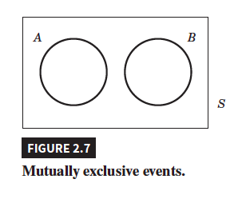

# Counting Techniques

## Counting Techniques

In the case where all possible outcomes are **equally likely** we often use counting techniques.

You probably used these techniques right now in the examples that we just discussed!

## Counting Techniques

The idea is very simple, we compute two quantities: The number of **favorable outcomes** in an event and the **total number of outcomes**

The probability of an event is:

$$P(E) = \frac{\text{Number of favorable outcomes}}{\text{Total number of outcomes}}$$

## Example: Throwing Three Coins

We toss a fair coin **three times**.

Each outcome is equally likely. The sample space is:

$$S = \{HHH,\ HHT,\ HTH,\ HTT,\ THH,\ THT,\ TTH,\ TTT\}$$

There are $2^3 = 8$ total outcomes.

## Example: Throwing Three Coins

Let’s count how many outcomes give:

- **0 heads**: TTT → 1 outcome
- **1 head**: HTT, THT, TTH → 3 outcomes
- **2 heads**: HHT, HTH, THH → 3 outcomes
- **3 heads**: HHH → 1 outcome

**Probability of 2 heads**:
$$P(\text{2 heads}) = \frac{3}{8}$$

## Counting groups

Then the main question becomes:

how to count different sets of outcomes?

## Multiplication Rule

The **Multiplication Rule** helps count the size of a **sample space** when an experiment consists of **multiple stages** or **steps**.

If an experiment has $ k $ stages, and

- Stage 1 has $ n_1 $ possible outcomes
- Stage 2 has $ n_2 $ outcomes
- …
- Stage $ k $ has $ n_k $ outcomes

then the **total number of outcomes** in the sample space is:
$$n_1 \times n_2 \times \dots \times n_k$$

## Example: Passwords

You want to create a 3-character password.

- First character: 26 options
- Second character: 26 options
- Third character: 26 options

**Total passwords** =
$$26 \times 26 \times 26 = 17,\!576$$

## Permutations of a Set

Permutations count the number of ways a set can be arranged.

If we have a set of $n$ elements, each position must be filled with a unique item:

- 1st position: $n$ choices
- 2nd position: $n - 1$ choices
- 3rd position: $n - 2$ choices
- …
- Last position: 1 choice

**Total permutations of $n$ objects:**

$$n! = n \times (n - 1) \times \dots \times 1$$

## Example: Deck of cards

In how many ways is it possible to shuffle a deck of cards?

$$n! = 52! = 8.0e67$$
(a lot)

## Permutations of a Subset

Sometimes we are only interested in the permutations of a subset rather than the full ordering. Suppose we are running a competition with 10 contestants, how many possible combinations exist for the podium?

- 1st place: 10 choices
- 2nd place: 9 choices
- 3rd place: 8 choices

$$10 \times 9 \times 8 = 720$$

## Permutations of a Subset

More generally:

**Permutations of $r$ items from $n$:**

$$P(n, r) = \frac{n!}{(n - r)!}$$

## Combinations

Sometimes we only care about selecting elements from a set, but the order does not matter.

In poker, a **hand** is a set of 5 cards drawn from a standard 52-card deck.  
**The order of the cards doesn’t matter.**

If we simply count all possible ways to draw 5 cards **in order**:

$$P(52, 5) = 52 \times 51 \times 50 \times 49 \times 48$$

That’s **all permutations** of 5 distinct cards, but we’re **overcounting**:  
Every group of 5 cards appears $5! = 120$ times in different orders.

So we need to divide the number of permutations by 120:

$$\frac{52 \times 51 \times 50 \times 49 \times 48}{5!} = 2,\!598,\!960$$

## Combinations

More generally: Combinations deal with the possible ways of selecting $r$ items from a set of $n$ items.

$$\binom{n}{r} = \frac{n!}{r!(n - r)!}$$

This is called a binomial, or “r choose n”.

## The Division Rule

How did we arrive at the formula for combinations?

If each valid outcome is counted $k$ times,  
then divide by $k$ to get the correct count.

$$\text{Correct count} = \frac{\text{Total arrangements}}{k}$$

This rule is often used when **order doesn’t matter**.

## Example: Poker Hands – cont.

What is the probability of drawing a **four of a kind** (a poker hand)?

The total number of possible hands is:
$$\binom{52}{5} = 2,\!598,\!960$$

### What is the total number of poker hands?

- Choose a **rank** for the 4 cards: $\binom{13}{1} = 13$
- Choose **4 suits** for that rank: $\binom{4}{4} = 1$
- Choose the 5th card from the **remaining 48** cards: $\binom{48}{1} = 48$

$$\text{Total} = 13 \times 1 \times 48 = 624$$

### Combining this together:

$$P(\text{four of a kind}) = \frac{624}{2,\!598,\!960} \approx 0.0002401$$

That’s approximately **1 in 4165** hands.

# Conditional Probability

Sometimes we are interested in the probability of an event  
**given that** another event has occurred.

The **conditional probability** of $A$ given $B$ is:

$$P(A \mid B) = \frac{P(A \cap B)}{P(B)} \quad \text{(if } P(B) > 0\text{)}$$

This tells us how likely $A$ is, **assuming we know** $B$ has happened.

## Example: Drawing cards

You draw one card from a standard 52-card deck.

Let:

- $A$: the card is a **queen**
- $B$: the card is a **face card** (J, Q, K → 12 cards)

What is $P(A \mid B)$?

Only 3 of the 12 face cards are queens:

$$P(A \mid B) = \frac{P(A \cap B)}{P(B)} = \frac{3/52}{12/52} = \frac{3}{12} = \frac{1}{4}$$

So:  
**If we know the card is a face card**,  
the probability that it is a queen is $\frac{1}{4}$.

## Example: Drawing Two Cards

You draw **two cards** from a standard 52-card deck **without replacement**.

Let:

- $A$: the **second card** is a heart
- $B$: the **first card** is a heart

What is $P(A \mid B)$?

What is the probability the second card is a heart, **given** the first card was a heart?

After drawing one heart, there are:

- **51 cards left**
- **12 hearts left**

So:

$$P(A \mid B) = \frac{12}{51}$$

The probability the **second card is a heart**,  
given that the first card **was a heart**, is:

$$P(A \mid B) = \frac{12}{51} \approx 0.235$$

## Law of Total Probability

Suppose events $B_1, B_2, \dots, B_n$ form a **partition** of the sample space:

- They are **mutually exclusive**
- Their union is the **entire sample space**

Then for any event $A$:

$$P(A) = \sum_{i=1}^{n} P(A \mid B_i) \cdot P(B_i)$$

This allows us to compute the probability of $A$  
by breaking it down into cases where each $B_i$ happens.

## Example: Covid testing

Suppose:

- 1% of a population has a disease: $P(D) = 0.01$
- 99% do not: $P(D^c) = 0.99$
- Test is 95% accurate:
  - $P(+ \mid D) = 0.95$
  - $P(+ \mid D^c) = 0.05$

What is the probability that a **random person tests positive**?

Using the law of total probability:

$$P(+) = P(+ \mid D) \cdot P(D) + P(+ \mid D^c) \cdot P(D^c)$$

$$= (0.95)(0.01) + (0.05)(0.99) = 0.059$$

So: **5.9%** of people test positive overall.

## Multiplication Rule

The probability of two events $A$ and $B$ both occurring is:

$$P(A \cap B) = P(A) \cdot P(B \mid A)$$

This comes directly from the definition of conditional probability:

$$P(B \mid A) = \frac{P(A \cap B)}{P(A)}$$

If you know $P(A)$ and the conditional probability of $B$ given $A$,  
you can compute the joint probability $P(A \cap B)$.

## Independence

Two events $A$ and $B$ are **independent** if:

$$P(B \mid A) = P(B)$$

and equivalently:

$$P(A \cap B) = P(A) \cdot P(B)$$

This means that knowing whether $A$ happened  
gives you **no information** about $B$, and vice versa.

# Bayes’ Theorem

Bayes’ Theorem allows us to **reverse conditional probabilities**:

$$P(B \mid A) = \frac{P(A \mid B) \cdot P(B)}{P(A)}$$

It’s most useful when:

- You know how likely $A$ is **given** $B$
- You want to compute how likely $B$ is **given** $A$

**Example** (from earlier):

If someone tests positive:

- What is the probability they actually have the disease?

Use Bayes’ Theorem:

$$P(D \mid +) = \frac{P(+ \mid D) \cdot P(D)}{P(+)}$$

## A Witness Reports a Blue Car

A hit-and-run occurs at night.

A witness claims the car was **blue**.  
They are known to correctly identify car colors **80% of the time**.

**Question**:  
What is the probability that the car was actually blue?

## But Here’s the Twist…

In this city:

- 85% of the cars are **green**
- 15% of the cars are **blue**

The witness always says **either blue or green**

And again:

- $P(\text{witness says "blue"} \mid \text{car is blue}) = 0.8$
- $P(\text{witness says "blue"} \mid \text{car is green}) = 0.2$

Let’s apply **Bayes’ Theorem**.

## Compute with Bayes

We want:

$$P(\text{Blue} \mid \text{Witness says Blue}) = \frac{P(\text{Witness says Blue} \mid \text{Blue}) \cdot P(\text{Blue})}{P(\text{Witness says Blue})}$$

We already know:

- $P(B) = 0.15$, $P(G) = 0.85$
- $P(W B) = 0.8 $, $P(W \mid G) = 0.2$

**Denominator**:

$$P(W) = (0.8)(0.15) + (0.2)(0.85) = 0.12 + 0.17 = 0.29$$

**Final result**:

$$P(B \mid W) = \frac{0.12}{0.29} \approx 0.41$$